# **Interpretation of the Plots**

## **$7^{th} Feb, 2025$**

## Name: Soumyadeep Ganguly

## Reg no: 24MDT0082

## **Multivariate Analysis on Titanic Dataset**

```python
import pandas as pd
import numpy as np
import seaborn as sns
import matplotlib.pyplot as plt
titanic=pd.read_csv("titanic.csv")
titanic.head()
```

|  | PassengerId | Survived | Pclass | Name | Sex | Age | SibSp | Parch | Ticket | Fare | Cabin | Embarked |
| --- | --- | --- | --- | --- | --- | --- | --- | --- | --- | --- | --- | --- |
| 0 | 1 | 0 | 3 | Braund, Mr. Owen Harris | male | 22.0 | 1 | 0 | A/5 21171 | 7.2500 | NaN | S |
| 1 | 2 | 1 | 1 | Cumings, Mrs. John Bradley (Florence Briggs Th... | female | 38.0 | 1 | 0 | PC 17599 | 71.2833 | C85 | C |
| 2 | 3 | 1 | 3 | Heikkinen, Miss. Laina | female | 26.0 | 0 | 0 | STON/O2. 3101282 | 7.9250 | NaN | S |
| 3 | 4 | 1 | 1 | Futrelle, Mrs. Jacques Heath (Lily May Peel) | female | 35.0 | 1 | 0 | 113803 | 53.1000 | C123 | S |
| 4 | 5 | 0 | 3 | Allen, Mr. William Henry | male | 35.0 | 0 | 0 | 373450 | 8.0500 | NaN | S |

```python
#percentage of women survived
women = titanic.loc[titanic.Sex == 'female']["Survived"]
rate_women = sum(women)/len(women)
#percentage of men survived
men = titanic.loc[titanic.Sex == 'male']["Survived"]

rate_men = sum(men)/len(men)
print(str(rate_women) +" % of women who survived." )
print(str(rate_men) + " % of men who survived." )
```

```
0.7420382165605095 % of women who survived.
0.18890814558058924 % of men who survived.
```

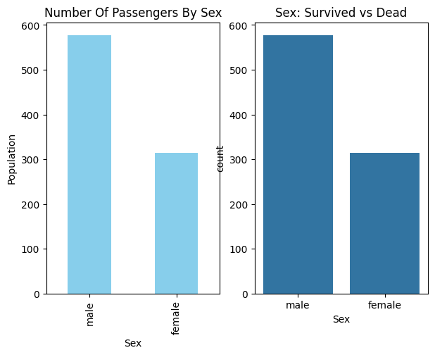

```python
titanic['Survived'] = titanic['Survived'].map({0:"not_survived", 1:"survived"})
fig, ax = plt.subplots(1, 2, figsize = (7, 5))
titanic["Sex"].value_counts().plot.bar(color = "skyblue", ax = ax[0])
ax[0].set_title("Number Of Passengers By Sex")
ax[0].set_ylabel("Population")
sns.countplot(x="Sex", data=titanic, ax = ax[1])
ax[1].set_title("Sex: Survived vs Dead")
plt.show()
```

### **Survival by Gender:**

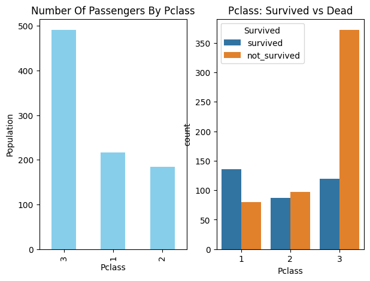

```python
fig, ax = plt.subplots(1, 2, figsize = (7, 5))
titanic["Pclass"].value_counts().plot.bar(color = "skyblue", ax = ax[0])
ax[0].set_title("Number Of Passengers By Pclass")
ax[0].set_ylabel("Population")
sns.countplot(x="Pclass", hue = "Survived", data = titanic, ax = ax[1])
ax[1].set_title("Pclass: Survived vs Dead")
plt.show()
```

### **Passenger Class Distribution and Survival Rate:**

```python
titanic["Embarked"] = titanic["Embarked"].fillna("S")
titanic.head(3)
```

|  | PassengerId | Survived | Pclass | Name | Sex | Age | SibSp | Parch | Ticket | Fare | Cabin | Embarked |
| --- | --- | --- | --- | --- | --- | --- | --- | --- | --- | --- | --- | --- |
| 0 | 1 | not_survived | 3 | Braund, Mr. Owen Harris | male | 22.0 | 1 | 0 | A/5 21171 | 7.2500 | NaN | S |
| 1 | 2 | survived | 1 | Cumings, Mrs. John Bradley (Florence Briggs Th... | female | 38.0 | 1 | 0 | PC 17599 | 71.2833 | C85 | C |
| 2 | 3 | survived | 3 | Heikkinen, Miss. Laina | female | 26.0 | 0 | 0 | STON/O2. 3101282 | 7.9250 | NaN | S |

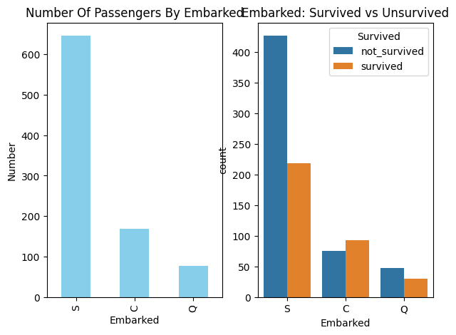

```python
fig, ax = plt.subplots(1, 2, figsize = (7, 5))
titanic["Embarked"].value_counts().plot.bar(color = "skyblue", ax = ax[0])
ax[0].set_title("Number Of Passengers By Embarked")
ax[0].set_ylabel("Number")
sns.countplot(x = "Embarked", hue = "Survived", data = titanic, ax = ax[1])
ax[1].set_title("Embarked: Survived vs Unsurvived")
plt.show()
```

## **Embarkation Analysis:**

The embarkation bar chart shows that most passengers boarded at 'S' (Southampton). The survival comparison plot indicates that embarkation location had some effect on survival, with passengers from Cherbourg ('C') having a higher survival rate.

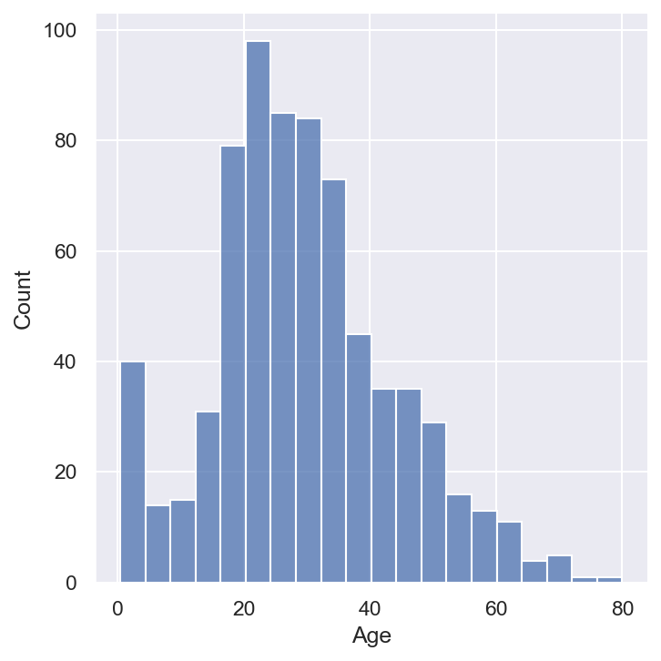

```python
sns.displot(titanic['Age'].dropna())
plt.show()
```

### **Age Distribution:**

The age distribution histogram highlights that most passengers were young adults, with fewer elderly passengers. This distribution is slightly right-skewed, meaning there were more younger individuals onboard. However, age itself does not seem to be a strong determinant of survival, though younger passengers, particularly children, had slightly better chances.

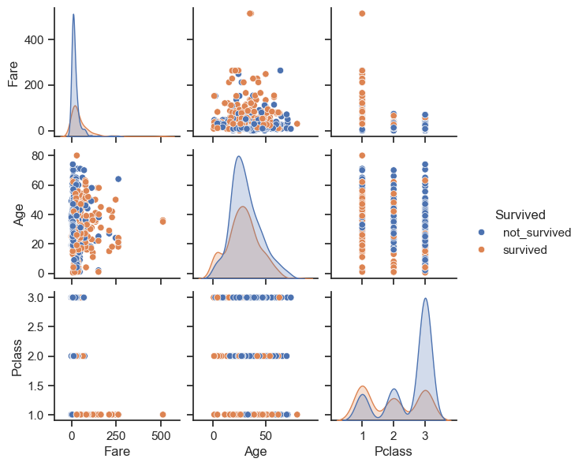

```python
sns.set(style="ticks", color_codes=True)
sns.pairplot(titanic,height=2,vars = [ 'Fare','Age','Pclass'], hue="Survived")
plt.show()
```

## **Pairplot Analysis (Fare, Age, Pclass, Survival):**

The pairplot analysis reveals that higher fares are associated with a greater likelihood of survival, indicating that wealthier passengers (often in first class) had better access to lifeboats. This relationship suggests a strong socio-economic influence on survival.

```python
titanic['Embarked'] = titanic['Embarked'].map({"S":1, "C":2,"Q":2,"NaN":0})
Tcorrelation = titanic.corr(method='pearson', numeric_only=True)
Tcorrelation
```

|  | PassengerId | Pclass | Age | SibSp | Parch | Fare | Embarked |
| --- | --- | --- | --- | --- | --- | --- | --- |
| PassengerId | 1.000000 | -0.035144 | 0.036847 | -0.057527 | -0.001652 | 0.012658 | -0.022204 |
| Pclass | -0.035144 | 1.000000 | -0.369226 | 0.083081 | 0.018443 | -0.549500 | -0.074053 |
| Age | 0.036847 | -0.369226 | 1.000000 | -0.308247 | -0.189119 | 0.096067 | 0.023233 |
| SibSp | -0.057527 | 0.083081 | -0.308247 | 1.000000 | 0.414838 | 0.159651 | -0.068734 |
| Parch | -0.001652 | 0.018443 | -0.189119 | 0.414838 | 1.000000 | 0.216225 | -0.060814 |
| Fare | 0.012658 | -0.549500 | 0.096067 | 0.159651 | 0.216225 | 1.000000 | 0.162184 |
| Embarked | -0.022204 | -0.074053 | 0.023233 | -0.068734 | -0.060814 | 0.162184 | 1.000000 |

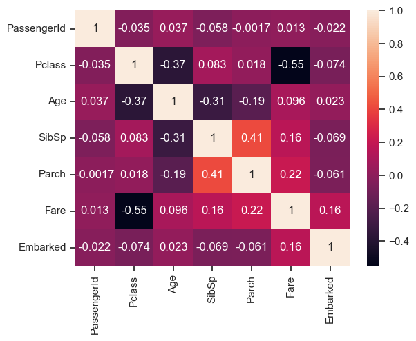

```python
sns.heatmap(Tcorrelation,xticklabels=Tcorrelation.columns,
 yticklabels=Tcorrelation.columns, annot=True)
```

## **Time Series Analysis: OPSD_germany_daily Dataset**

```python
import pandas as pd
import numpy as np

# load time series dataset
df_power = pd.read_csv("opsd_germany_daily.csv")
print(df_power.columns)
df_power.tail(10)
```

```
Index(['Date', 'Consumption', 'Wind', 'Solar', 'Wind+Solar'], dtype='object')
```

|  | Date | Consumption | Wind | Solar | Wind+Solar |
| --- | --- | --- | --- | --- | --- |
| 4373 | 2017-12-22 | 1423.23782 | 228.773 | 10.065 | 238.838 |
| 4374 | 2017-12-23 | 1272.17085 | 748.074 | 8.450 | 756.524 |
| 4375 | 2017-12-24 | 1141.75730 | 812.422 | 9.949 | 822.371 |
| 4376 | 2017-12-25 | 1111.28338 | 587.810 | 15.765 | 603.575 |
| 4377 | 2017-12-26 | 1130.11683 | 717.453 | 30.923 | 748.376 |
| 4378 | 2017-12-27 | 1263.94091 | 394.507 | 16.530 | 411.037 |
| 4379 | 2017-12-28 | 1299.86398 | 506.424 | 14.162 | 520.586 |
| 4380 | 2017-12-29 | 1295.08753 | 584.277 | 29.854 | 614.131 |
| 4381 | 2017-12-30 | 1215.44897 | 721.247 | 7.467 | 728.714 |
| 4382 | 2017-12-31 | 1107.11488 | 721.176 | 19.980 | 741.156 |

```python
print(df_power.shape)
print(df_power.dtypes)
```

```
(4383, 5)
Date            object
Consumption    float64
Wind           float64
Solar          float64
Wind+Solar     float64
dtype: object
```

```python
#convert object to datetime format
df_power['Date'] = pd.to_datetime(df_power['Date'])
```

```python
df_power = df_power.set_index('Date')
df_power.tail(3)
```

| Date | Consumption | Wind | Solar | Wind+Solar |
| --- | --- | --- | --- | --- |
| 2017-12-29 | 1295.08753 | 584.277 | 29.854 | 614.131 |
| 2017-12-30 | 1215.44897 | 721.247 | 7.467 | 728.714 |
| 2017-12-31 | 1107.11488 | 721.176 | 19.980 | 741.156 |

```python
df_power.index
```

```
DatetimeIndex(['2006-01-01', '2006-01-02', '2006-01-03', '2006-01-04',
               '2006-01-05', '2006-01-06', '2006-01-07', '2006-01-08',
               '2006-01-09', '2006-01-10',
               ...
               '2017-12-22', '2017-12-23', '2017-12-24', '2017-12-25',
               '2017-12-26', '2017-12-27', '2017-12-28', '2017-12-29',
               '2017-12-30', '2017-12-31'],
              dtype='datetime64[ns]', name='Date', length=4383, freq=None)
```

```python
# Add columns with year, month, and weekday name
df_power['Year'] = df_power.index.year
df_power['Month'] = df_power.index.month
df_power['Weekday Name'] = df_power.index.day_name
```

```python
df_power.sample(5, random_state=0)
```

| Date | Consumption | Wind | Solar | Wind+Solar | Year | Month | Weekday Name |
| --- | --- | --- | --- | --- | --- | --- | --- |
| 2008-08-23 | 1152.011 | NaN | NaN | NaN | 2008 | 8 | <bound method _inherit_from_data.<locals>.meth... |
| 2013-08-08 | 1291.984 | 79.666 | 93.371 | 173.037 | 2013 | 8 | <bound method _inherit_from_data.<locals>.meth... |
| 2009-08-27 | 1281.057 | NaN | NaN | NaN | 2009 | 8 | <bound method _inherit_from_data.<locals>.meth... |
| 2015-10-02 | 1391.050 | 81.229 | 160.641 | 241.870 | 2015 | 10 | <bound method _inherit_from_data.<locals>.meth... |
| 2009-06-02 | 1201.522 | NaN | NaN | NaN | 2009 | 6 | <bound method _inherit_from_data.<locals>.meth... |

```python
df_power.loc['2015-10-02']
```

```
Consumption                                               1391.05
Wind                                                       81.229
Solar                                                     160.641
Wind+Solar                                                 241.87
Year                                                         2015
Month                                                          10
Weekday Name    <bound method _inherit_from_data.<locals>.meth...
Name: 2015-10-02 00:00:00, dtype: object
```

```python
df_power.loc['2017-01-01':'2017-12-30']
```

| Date | Consumption | Wind | Solar | Wind+Solar | Year | Month | Weekday Name |
| --- | --- | --- | --- | --- | --- | --- | --- |
| 2017-01-01 | 1130.41300 | 307.125 | 35.291 | 342.416 | 2017 | 1 | <bound method _inherit_from_data.<locals>.meth... |
| 2017-01-02 | 1441.05200 | 295.099 | 12.479 | 307.578 | 2017 | 1 | <bound method _inherit_from_data.<locals>.meth... |
| 2017-01-03 | 1529.99000 | 666.173 | 9.351 | 675.524 | 2017 | 1 | <bound method _inherit_from_data.<locals>.meth... |
| 2017-01-04 | 1553.08300 | 686.578 | 12.814 | 699.392 | 2017 | 1 | <bound method _inherit_from_data.<locals>.meth... |
| 2017-01-05 | 1547.23800 | 261.758 | 20.797 | 282.555 | 2017 | 1 | <bound method _inherit_from_data.<locals>.meth... |
| ... | ... | ... | ... | ... | ... | ... | ... |
| 2017-12-26 | 1130.11683 | 717.453 | 30.923 | 748.376 | 2017 | 12 | <bound method _inherit_from_data.<locals>.meth... |
| 2017-12-27 | 1263.94091 | 394.507 | 16.530 | 411.037 | 2017 | 12 | <bound method _inherit_from_data.<locals>.meth... |
| 2017-12-28 | 1299.86398 | 506.424 | 14.162 | 520.586 | 2017 | 12 | <bound method _inherit_from_data.<locals>.meth... |
| 2017-12-29 | 1295.08753 | 584.277 | 29.854 | 614.131 | 2017 | 12 | <bound method _inherit_from_data.<locals>.meth... |
| 2017-12-30 | 1215.44897 | 721.247 | 7.467 | 728.714 | 2017 | 12 | <bound method _inherit_from_data.<locals>.meth... |

364 rows × 7 columns

```python
sns.set(rc={'figure.figsize':(16, 4)})
plt.rcParams['figure.dpi'] = 150
```

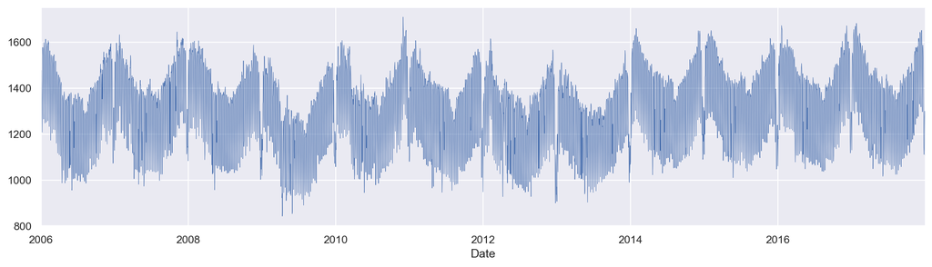

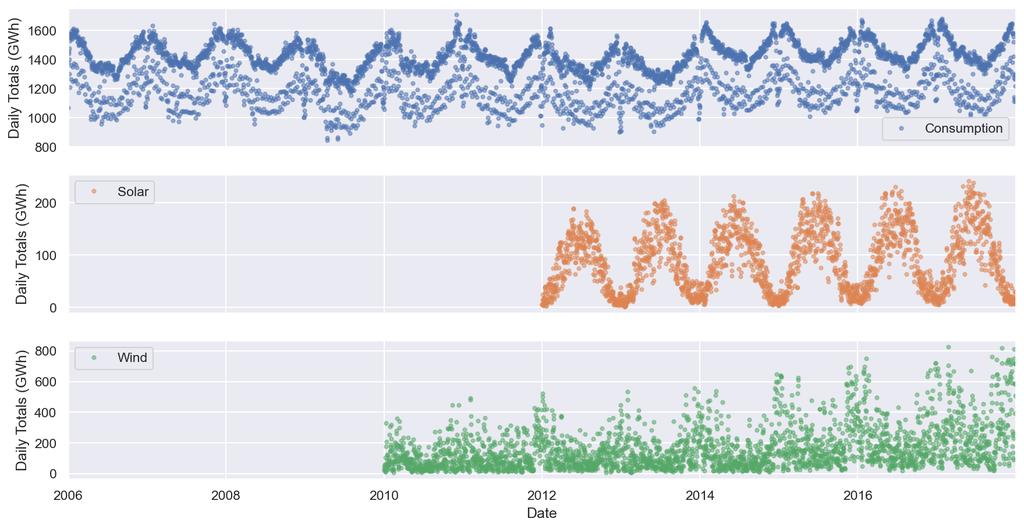

```python
df_power['Consumption'].plot(linewidth=0.4)

cols_to_plot = ['Consumption', 'Solar', 'Wind']
axes = df_power[cols_to_plot].plot(marker='.', alpha=0.5, linestyle='None',figsize=(14, 7), subplots=True)
for ax in axes:
    ax.set_ylabel('Daily Totals (GWh)')
```